# Cours Angular

sombre

## Introduction

*Une application Angular est une arborescence de composants…*

### Présentation générale

Suivez l’introduction générale dans le document Angular - Introduction.pdf.

Retrouvez le cours au format HTML en un fichier.

### Documentation

- [Site officiel](https://angular.io/)
  - [Guide](https://angular.io/start)
  - [Cheat Sheet](https://angular.io/guide/cheatsheet)
  - [Angular CLI](https://angular.io/cli)
  - [Tutoriel](https://angular.io/tutorial)
  - [Glossaire](https://angular.io/guide/glossary)
  - [Exemples utilisés dans la documentation](https://angular.io/guide/example-apps-list)

## Applications web monopage (*Single Page Applications*)

Une « [Application web monopage](https://fr.wikipedia.org/wiki/Application_web_monopage) » (*Single Page Application*) est un site web qui reste sur une seule page sans jamais recharger la page (on ne voit jamais l’icône de rafraîchissement de page du navigateur s’animer). Le contenu additionnel (non chargé initialement) est téléchargé via des requêtes HTTP en tâche de fond (« Ajax ») et injecté dans le DOM.

On ne recharge jamais une page complète, on charge seulement le contenu (article ou résultat de recherche qui s’affiche dans la page) ou l’information nécessaire, au bon moment (ex : connexion réussie, saisie invalide dans un champ, etc.).

Les données à sauvegarder peuvent être envoyées à un serveur en HTTP ou sauvegardées localement. Dans le premier cas, le serveur doit être configuré pour communiquer avec une base de données et avec l’application SPA (typiquement via une [API REST](https://fr.wikipedia.org/wiki/Representational_state_transfer) HTTP).

### Avantages

- Économie de bande passante (serveur et client) : on ne recharge pas les mêmes éléments d’interface,
- Économie de resources serveur, on déporte les actions légères sur le client,
- Application plus réactive pour l’utilisateur (le code est déjà chargé).

### Le routage

On utilise le « routage » pour associer des vues à des URL. Une « route » est constituée :

- d’une adresse web (URL) ou fragment d’adresse permettant de reconstituer une URL,
- d’un composant ou d’un module qui sera chargé quand on accède à cette URL,
- des règles (facultatives) régissant l’accès à cette route (*guard*).

## Installation de l’environnement Angular

### Pré-requis : Node.js

On doit d’abord installer [Node.js](https://nodejs.org/), un environnement d’exécution en JavaScript utilisé pour créer des applications serveur, desktop ou embarquées.

Le gestionnaire de paquets [npm](https://www.npmjs.com/) (*Node Package Manager*) sera également installé avec Node.js. Npm est le logiciel en ligne de commande avec lequel nous allons installer Angular et ses dépendances.

Node.js est nécessaire pour utiliser les outils de développement, disposer d’un serveur HTTP de test pour nos applications et exécuter des tâches de construction et de maintenance.

Nous installerons la version LTS (*Long Term Support*) courante de Node.js et npm.

Pour ce cours nous utiliserons les logiciels suivants dans les versions indiquées :

- **Node.js** 14.x (LTS)
- **npm** 7.x
- **Angular** 12.x

#### Vérifier la bonne installation de Node.js et npm

Version de Node.js installée

```
node --version
```

Version de npm installée

```
npm --version
```

### Installation du CLI Angular

On utilisera le logiciel officiel proposé par Angular pour générer des applications et des contenus Angular (composants, services, directives, etc.), pour tester les applications avec un server de développement, et pour produire la version à publier.

[Angular CLI](https://cli.angular.io/) est un outil en ligne de commande (*Command Line Interface*), c’est-à-dire un programme sans interface graphique, qui s’utilise en saisissant des commandes en texte dans un terminal comme par exemple :

- Bash (Linux)
- Terminal (macOS)
- cmd (Windows)
- PowerShell (Windows 7+, Linux, macOS)
- Git Bash (Windows, Linux, macOS)

On installe @angular/cli globalement afin de pouvoir créer des projets Angular.

```
npm install -g @angular/cli
```

#### Vérifier la version installée

Le programme en ligne de commande installé par le paquet `@angular/cli` s’appelle **`ng`**.

Si l’installation a réussi, on a accès au programme en ligne de commande avec la commande `ng`. Pour le vérifier, on peut demander à afficher la version du programme.

```
ng --version
```

#### Documentation

Une documentation des commandes disponibles peut être affichée dans la console avec la commande

```
ng help
```

Une [documentation complète](https://angular.io/cli) est disponible en ligne.

## Linter (ESLint)

Un *linter* est un programme qui fait une analyse statique du code source afin de détecter des erreurs de programmation, des bugs, des erreurs de style et des mauvaises pratiques.

Le *linter* analyse le code en continu dans votre IDE afin d’éviter d’écrire du mauvais code et peut aussi être exécuté avant la compilation ou la construction de l’application.

### ESLint dans Angular

Historiquement il existait un linter dédié à TypeScript (TSLint) mais il a été remplacé par le linter de JavaScript (ESLint).

Les nouveaux projets Angular ne comportent plus de linter par défaut, mais Angular propose une configuration officielle de ESLint adaptée aux projets Angular.

Pour l’installer, il suffit d’exécuter la commande suivante dans le dossier du projet :

```bash
ng add @angular-eslint/schematics
```

Pour plus d’information sur la configuration ESLint des projets Angular (en particulier pour les versions antérieures à Angular 12), consultez le [dépôt officiel](https://github.com/angular-eslint/angular-eslint).

### Extension pour Visual Studio Code

Pour bénéficier du linter en temps réel dans votre IDE, installez l’extension [ESLint pour Visual Studio Code](https://marketplace.visualstudio.com/items?itemName=dbaeumer.vscode-eslint).

## Le CLI Angular

Angular propose un outil en ligne de commande qui permet, entre autres de :

- générer des projets,
- générer des éléments au sein d’une application (composants, services, directives, etc.),
- démarrer un serveur de développement,
- exécuter les tests unitaires,
- produire l’application de production,
- mettre à jour le framework…

### Créer un nouveau projet

Pour créer un nouveau projet on exécute la commande `ng new <NOM_DU_DOSSIER>`. Cette commande :

- crée le dossier spécifié,
- installe localement les dépendances (paquets npm),
- crée un squelette d’application Angular prête à fonctionner.

```
ng new angular-demo
```

[Documentation de la commande `new`](https://angular.io/cli/new).

Le CLI installe ensuite les dépendances, ce qui peut prendre plusieurs minutes.

Pour travailler dans le dossier du projet on se place dans le dossier créé, avec la commande `cd` :

```
cd angular-demo
```

On peut obtenir l’aide du programme avec la commande :

```
ng help
```

On peut aussi obtenir de l’aide sur une fonction spécifique en indiquant le nom de la commande (ci-dessous `generate`) suivi de l’option `--help` :

```
ng generate --help
```

### Démarrer un serveur de test

Pour tester l’application en cours de développement, le CLI peut démarrer un petit server HTTP avec un système de *live-reload* qui permet de rafraîchir le navigateur à chaque enregistrement d’un fichier source.

```
ng serve
```

Par défaut le serveur est disponible à l’adresse http://localhost:4200/.

Pour arrêter le serveur : `Ctrl + C` dans le terminal qui exécute le serveur.

### Utilisation du CLI d’Angular pour générer des parties de l’application

Le CLI d’Angular permet de créer des applications basées sur des modèles prédéfinis mais aussi, à l’intérieur de l’application, de créer des composants et autres types d’éléments d’une application Angular.

#### Générer un contenu (*code scaffolding*)

La commande `ng generate` crée un type de contenu Angular (composant, service, directive, filtre, garde…). Le nom du type de structure sera suffixé au nom indiqué. Par exemple la commande:

```
ng generate service user
```

Créera un service dont la classe aura pour nom « UserService ».

Note : les noms de classes commencent toujours par une majuscule par convention (PascalCase). Les noms de fichiers et de dossiers sont générés avec des tirets (kebab-case).

```
ng generate component fiche-produit
```

La commande ci-dessus produira la classe `FicheProduitComponent` dans le fichier `fiche-produit.component.ts` dans un nouveau dossier `fiche-produit` (qui contiendra aussi d’autres fichiers en fonction de la configuration de votre projet) dans `src/app`.

On peut spécifier un chemin indiquant l’emplacement du composant à générer. Les dossiers qui n’existent pas seront créés.

```
ng generate component features/catalog/fiche-produit
```

La commande ci-dessus créera le dossier `features` et le sous-dossier `catalog` s’ils n’existent pas.

[Documentation de la commande `generate`](https://angular.io/cli/generate#ng-generate).

### Générer l’application à publier

Pour générer une version prête à publier (mettre en ligne) on utilisera la commande `ng build`. Cette commande génère l’application dans un dossier nommé « dist », à la racine du projet. Pour créer une version optimisée prête à mettre en ligne on utilisera le flag `--prod`.

```
ng build --prod
```

Le contenu du dossier `./dist` peut être directement mis en ligne sur un hébergement adapté.

[Documentation de la commande `build`](https://angular.io/cli/build#ng-build).

### Documentation

- [Reference des commandes du CLI Angular](https://angular.io/cli)
  - [Aperçu des commandes](https://angular.io/cli#command-overview)

## Déboguer une application Angular

Lorsqu’on développe une application web on doit toujours ouvrir les outils de développement dans le navigateur et en particulier la console, pour repérer immédiatement :

- les erreurs de syntaxe (qui font planter l’application),
- certaines erreurs de logique (valeurs « undefined »),
- les messages informatifs affichés par le navigateur ou le framework.

De même, on garde un œil sur le terminal où on a démarré le serveur de test, qui peut afficher des informations liées à la compilation TypeScript ou des messages du serveur de test.

Lorsqu’on développe, on teste chaque modification du code afin de repérer les erreurs le plus tôt possible. Si on ne respecte pas cette règle, on peut découvrir une erreur en aval, qui peut provenir d’une dizaine de modifications faites en amont.

Si on respecte ce principe, (*test early, test often*) l’erreur provient certainement du dernier changement effectué.

### Lire les messages de la console

Si une erreur s’affiche dans la console, il est important de **lire le message**. Les erreurs provenant d’Angular fournissent des informations sur le fichier à l’origine de l’erreur et même le numéro de ligne.

### Référence des erreurs Angular

La documentation d’Angular propose une [liste des erreurs](https://angular.io/errors) courantes numérotées. Lorsque vous rencontrez cette erreur, Angular ajoute un lien vers la page exacte décrivant la nature de l’erreur et les corrections possibles.

Certaines pages sont accompagnées d’une vidéo. Vous retrouverez toutes ces vidéos sur la [chaîne YouTube d’Angular](https://www.youtube.com/channel/UCbn1OgGei-DV7aSRo_HaAiw) ainsi que des tutoriels et des des informations sur les évolutions d’Angular.

### Sourcemaps

Angular, en mode développement, produit des *sourcemaps* qui peuvent être exploités dans les outils de développement des navigateurs, via l’onglet « Sources ».

Dans la partie « Webpack:// » vous retrouverez toute la structure de votre application. Vous pourrez donc ouvrir un fichier pour y ajouter des *breakpoints*.

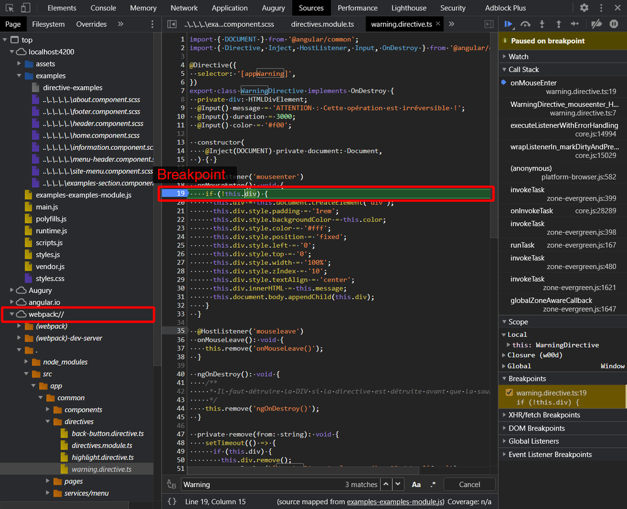

### Angular DevTools

[Angular DevTools](https://chrome.google.com/webstore/detail/angular-devtools/ienfalfjdbdpebioblfackkekamfmbnh) est une extension pour Chrome qui permet de déboguer et profiler les applications Angular.

#### Documentation

- [DevTools Overview](https://angular.io/guide/devtools)

## Les composants (introduction)

Les composants sont les blocs de base qui régissent l’affichage d’une application Angular. Ce sont les unités de code ré-utilisables qui définissent l’interface utilisateur comme par exemple : - des fragments de mise en page comme l’en-tête ou le pied de page d’un site - des éléments d’interface réutilisables comme des boutons, menus déroulants, fenêtres modales - des contenus paramétrables comme un bouton qui peut intégrer une icône, avoir des tailles ou couleur différente différentes, mais avec une base fonctionnelle et visuelle commune

Ils sont définis en 3 parties : - l’interface utilisateur (template HTML), - son style (fragment de CSS), - la logique associée (une classe TypeScript).

Les composants peuvent être très simples (comme un simple bouton avec une fonction exécutée au clic) ou complexes, comme par exemple un composant définissant un menu déroulant ou même une page entière de l’application (associée à une URL via le routage). Un composant complexe sera composé de préférence à partir de composants simples.

### Les méta-données

Un composant est définit par une classe qui possède le décorateur `@Component()` qui, au minimum, associe la classe à un template (HTML). L’ensemble classe et template définit une *vue*, c’est-à-dire une partie visible du site.

### Les sélecteurs

Lorsqu’on crée un composant Angular, on définit le sélecteur qui permettra d’afficher ce composant dans la page HTML qui contient notre application.

La forme des sélecteurs est basée sur la syntaxe CSS.

- `app-comments` cible les éléments nommés `app-comments`
- `.app-comments` cible les éléments portant la classe `app-comments`
- `[app-comments]` cible les éléments portant l’attribut `app-comments`

```
import { Component, OnInit } from '@angular/core';

@Component({
  selector: 'app-comments', // Ce sélecteur permet d’afficher le composant sous la forme d’un élément.
  templateUrl: './comments.component.html',
  styleUrls: ['./comments.component.scss']
})
export class CommentsComponent implements OnInit {
}
```

Le sélecteur défini pourra être utilisé pour afficher le composant dans une partie de notre application : soit dans le composant racine, soit dans un composant enfant.

#### Exemple d’utilisation dans un template Angular

```
<app-comments></app-comments>
```

#### Sélecteur de classe

```
selector: '.app-comments', // Ce sélecteur permet d’afficher le composant sous la forme d’une classe.
```

##### Exemple d’utilisation dans un template Angular

```
<div class="app-comments"></div>
```

#### Sélecteur d’attribut

```
selector: '[app-comments]', // Ce sélecteur permet d’afficher le composant sous la forme d’un attribut.
```

##### Exemple d’utilisation dans un template Angular

```
<div app-comments></div>
```

### Module

Chaque composant doit être déclaré dans un module (tableau `declarations` du décorateur `NgModule`) et ne peut pas être déclaré dans plusieurs modules.

### Documentation

#### Guide

- [Introduction aux composants](https://angular.io/guide/component-overview)
- [Styler les composants](https://angular.io/guide/component-styles#component-styles)

## Les directives (introduction)

Dans Angular, une directive est une classe qui permet de modifier la structure du DOM ou de modifier les attributs ou propriétés d’un élément du DOM.

Une directive est définie par une classe qui porte le décorateur `@Directive` qui fournit les métadonnées utilisées par la directive.

Une directive s’utilise sous la forme d’un mot-clé (le sélecteur) appliqué dans un template, sous la forme d’un élémént ou d’un attribut, pour modifier le comportement de l’élément ciblé. Lorsqu’Angular rencontre dans un template HTML un sélecteur correspondant à une directive, il instancie la classe correspondante et applique le comportement défini par la directive.

Il y a trois catégories de directives:

- Les composants utilisent le décorateur `@Component()` (une extension de `@Directive()`) pour associer un template à une classe.
- Les directives d’attribut modifient le comportement ou l’apparence d’un élément.
- Les directives structurelles modifient la structure du DOM (insèrent ou suppriment des éléments du DOM).

Les composants sont donc un type particulier de directive (la différence est qu’un composant possède un template).

Angular fournit de base plusieurs directives qui commencent par le préfixe ng (comme `NgClass`). Vous pouvez également créer de nouvelles directives pour implémenter vos propres fonctionnalités. Vous associez un sélecteur (un attribut comme `<div maDirective></div>`) à un élément, étendant ainsi la syntaxe disponible pour les templates de vos applications.

### Documentation

#### API

- [Le décorateur `@Directive`](https://angular.io/api/core/Directive)
- [Liste des directives fournies par Angular](https://angular.io/api?type=directive)

#### Guide

- [Les directives structurelles](https://angular.io/guide/structural-directives)
- [Les directives d’attribut](https://angular.io/guide/attribute-directives#attribute-directives)
- [Directives les plus couramment utilisées](https://angular.io/guide/built-in-directives#built-in-directives)

#### Glossaire

Dans Angular, l’interpolation consiste à évaluer l’expression entres doubles accolades et à afficher la valeur obtenue en tant que texte.

L’expression suivante, placée dans un template de composant, affichera le résultat de l’évaluation de l’expression `1 + 1` comme contenu (nœud texte) du paragraphe.

```
<p>{{ 1 + 1 }}</p>
```

La syntaxe des expressions de template resemble à celle de JavaScript. De nombreuses expressions JavaScript peuvent être évaluées dans un template Angular via l’interpolation.

Les expressions peuvent utiliser la concaténation, les opérateurs de comparaison et les opérateurs de calculs logiques…

Il existe plusieurs exceptions. En particulier on ne peut pas utiliser des expressions qui ont ou qui peuvent avoir des effets secondaires, comme :

- des assignations (`=`, `+=`, `-=`, …)
- les opérateurs comme `new`, `typeof`, `instanceof`, etc.
- l’incrémentation (`++`) ou la décrémentation ( `--`).
- certains opérateurs ES2015+

Les expressions de template ne peuvent pas faire référence à l’espace de noms global. Elles ne peuvent pas faire référence à `window` ni à `document`. De plus, elles ne peuvent pas utiliser les objets fondamentaux de JavaScript (comme `Math` ou `Date`).

### Invocation de méthodes

L’interpolation peut également être utilisée pour invoquer (c’est à dire entraîner l’exécution) d’une méthode de la classe du composant.

L’interpolation affichera alors la valeur de retour de la méthode invoquée et cette valeur sera affichée sous forme de texte.

### Documentation

#### Guide

- [L’interpolation](https://angular.io/guide/interpolation)
  - [Les expressions](https://angular.io/guide/interpolation#template-expressions)
- [La syntaxe de template](https://angular.io/guide/template-syntax)
- https://angular.io/guide/template-syntax#more-on-template-syntax

#### Glossaire

- [Interpolation](https://angular.io/guide/glossary#interpolation)

## Les variables de template

Avec les variables de template on obtient une référence à l’élément qui porte la référence, on peut donc accéder à toutes les propriétés de cet élément HTML.

```
<input type="text" name="nom" #inputElementRef>
{{ inputElementRef.name }} <!-- Affichera « nom » qui est la valeur de l’attribut « name » qui est une propriété de l’input (objet DOM) -->
```

**Note :** La variable est valide dans le contexte du template. Le nom de cette variable doit être unique pour ne pas entrer en conflit avec d’autres références dans le même template.

**Note :** Les variables de template peuvent aussi pointer vers des directives, comme `ngModel` ou `ngForm` (voir la section sur les formulaires), qui lui assignent une valeur différente de l’élément HTML. Nous verrons des exemples avancés de variables de template associées à des directives dans la partie sur les formulaires.

### Documentation

#### Guide

- [Les variables de template (*template reference variable*)](https://angular.io/guide/template-reference-variables)

## La directive `NgIf`

La directive `NgIf` permet de supprimer ou d’insérer un élément du DOM.

La directive `NgIf` prend en paramètre une expression qui sera évaluée à une valeur booléenne : si la valeur obtenue est `false` le nœud DOM est supprimé (ou n’est pas inséré s’il n’a pas encore été inséré), si la valeur obtenue est `true` le nœud DOM est inséré à l’endroit ou la directive est utilisée.

La syntaxe de la directive prend la forme `*ngIf="expression"` où `expression` doit être une expression Angular valide (qui peut résulter en un booléen):

```
<p *ngIf="'a' === 'a'">Identité vérifiée</p>
```

On peut utiliser toute expression valide en Angular :

```
<p *ngIf="4 % 2 === 0">4 est divisible par 2</p>
```

y compris des appels de fonctions, tant qu’ils retournent un booléen :

```
<p *ngIf="isGoodPerson()">Bienvenue</p>
```

Avec l’expression suivante, la `<div>` ne sera jamais affichée :

```
<div *ngIf="0">Nul !</div>
```

On peut avoir besoin d’afficher une information si l’expression est vraie et une autre si l’expression est fausse

Dans les cas simples on peut envisager d’écrire les 2 cas sur 2 éléments :

```
<div *ngIf="isAdmin()"><a href="/admin/">Par ici</a></div>
<div *ngIf="!isAdmin()">Accès réservé</div>
```

Mais il est souvent plus rationnel de concevoir cette logique sous la forme `if` / `else` comme en JavaScript afin de formaliser la relation entre des éléments liés par une logique commune.

Angular le permet avec une syntaxe qui fait appel à l’élément `<ng-template>` pour afficher le contenu alternatif.

`<ng-template>` est un élément qui permet de faire un rendu conditionnel : il n’est jamais affiché directement et son contenu est affiché uniquement si le `<ng-template>` est appellé par exemple dans la clause `else` d’un `*ngIf`.

Pour l’utiliser avec `NgIf` il faut nommer ce template en utilisant une variable de template :

```
<ng-template #nomDuTemplate>
```

Exemple d’utilisation :

```
<p *ngIf="age >= 25; else interdit">Vous pouvez louer une voiture.</p>

<ng-template #interdit>
  <p>Vous êtes encore trop jeune !</p>
</ng-template>
```

Dans l’exemple ci-dessus, la propriété âge contient un nombre. Si le nombre est supérieur ou égal à 25 alors la condition est vraie et l’élément qui porte la directive `NgIf` est affiché. Puisque le template « interdit » n’est jamais appellé, il n’est jamais rendu dans le DOM.

Si la condition du `NgIf` est fausse (la valeur de la propriété `age` est inférieurs à 25), alors la clause `else` est activée et le template qui porte le nom « interdit » est affiché à la place du paragraphe qui porte la directive `NgIf`. Dans ce cas uniquement le paragraphe contenu dans le `<ng-template #interdit>` sera affiché dans le DOM.

Notez que le `#` n’est utilisé que lors de la déclaration du nom du template, pas quand on fait référence à ce nom, comme dans la clause `else`.

### Documentation

#### API

- [La directive `NgIf`](https://angular.io/api/common/NgIf)

#### Guide

- [Affichage conditionnel avec `NgIf`](https://angular.io/guide/displaying-data#conditional-display-with-ngif)
- [Les directives structurelles](https://angular.io/guide/structural-directives#structural-directives)
- [l’élément](https://angular.io/guide/structural-directives#the-ng-template)

## La directive `NgFor`

La directive `NgFor` permet de répéter un élément du DOM pour chaque élément d’une collection (tableau ou autre objet itérable). L’élément HTML portant la directive `NgFor` est répliqué et injecté dans le DOM autant de fois qu’il y a d’éléments dans le tableau.

L’exemple ci-dessous créera autant d’éléments `<li>` qu’il y a d’éléments dans le tableau `movieCollection`.

```
<ul>
  <li *ngFor="let movie of movieCollection">{{ movie.title }}</li>
</ul>
```

Pour chaque élément de la liste de films (`movieCollection`) on obtient la valeur en cours sous le nom `movie`. Si l’élément en question est un objet, on peut afficher ses propriétés avec la syntaxe `.` comme pour n’importe quel objet.

La syntaxe Angular s’inspire évidemment de la syntaxe JavaScript [`for...of`](https://developer.mozilla.org/en-US/docs/Web/JavaScript/Reference/Statements/for...of).

Il est aussi possible d’obtenir d’autres informations utiles dans le contexte de cette boucle :

- `index` : l’indice de l’élément en cours,
- `count`: nombre correspondant au nombre d’éléments dans le tableau,
- `first` : booléen `true` si l’élément est à la première position,
- `last` : booléen `true` si l’élément est à la dernière position,
- `odd` : booléen `true` si l’élément a un indice impaire,
- `even` : booléen `true` si l’élément a un indice paire.

### Documentation

#### API

- NgForOf

#### Guide

- [La directive NgFor](https://angular.io/guide/built-in-directives#ngfor).
- [La microsyntaxe NgFor](https://angular.io/guide/structural-directives#microsyntax).

## Les filtres (*pipes*)

Les filtres (*pipes* en anglais) sont des fonctions de transformation qui prennent une valeur en argument et qui retournent une valeur modifiée.

Angular prévoit de pouvoir utiliser ces fonctions directement dans un template sur une valeur à afficher dans une expression. Pour utiliser un filtre on écrit le caractère barre verticale (`|`, *pipe* en anglais) après une valeur dans une expression, suivi du nom du filtre.

Angular fourni plusieurs filtres répondant à des besoins courants, comme :

- [`CurrencyPipe`](https://angular.io/api/common/CurrencyPipe) pour l’affichage des valeurs monétaires
- [`DatePipe`](https://angular.io/api/common/DatePipe) pour formater les dates
- [`SlicePipe`](https://angular.io/api/common/SlicePipe) pour afficher une partie d’un tableau ou itérable.

Par ailleurs vous pouvez créer vos propres filtres.

### Documentation

#### API

- [Liste des filtres fournis par Angular](https://angular.io/api?type=pipe)

#### Guide

- [Transformer des données avec les filtres](https://angular.io/guide/pipes)

## La liaison de propriété (*property binding*)

**De la source de données (classe TypeScript) vers la vue (template HTML)**

Il y a 2 formes de liaison de données dans ce sens.

L’interpolation permet uniquement de produire des chaînes de caractères.

```
{{ expression }}
```

La liaison de propriété permet de lier des booléens, nombres ou objets.

```
[target]="expression"
```

En HTML on peut définir les propriétés de certains éléments en utilisant des attributs dans la balise ouvrante de cet élément, comme l’attribut `src` pour la balise `img`, qui permet de spécifier la source de l’image à afficher. La valeur d’un attribut HTML est toujours du texte.

Angular permet de lier une *propriété* d’un élément DOM à une propriété de la classe du composant. Cela signifie qu’on peut lier tout type de donnée, y compris des tableaux, des booléens ou n’importe quel objet.

#### Différence entre *attribut* HTML et *propriété* d’un objet DOM

Un **attribut** est une partie de la balise, écrite en texte dans le code source, qui sert à générer le DOM. Une **propriété** d’un élément est une propriété d’un objet généré par le DOM et manipulable en JavaScript. Les attributs sont un moyen pour fournir des valeurs aux éléments du DOM. Par exemple, l’attribut `src` en texte dans le code source fournit la valeur associée à la propriété du même nom pour le nœud DOM de type [`Image`](https://developer.mozilla.org/en-US/docs/Web/API/HTMLImageElement) créé par le navigateur.

Angular s’inspire de cette syntaxe familière, celle des attributs, pour nous permettre de manipuler dynamiquement des propriétés des éléments DOM.

#### Exemple

Lorsqu’on veut affecter la valeur d’une propriété d’élément à partir d’une propriété du composant on utilise des crochets `[]`, par exemple pour la propriété `src` d’une image on écrira :

```
<img [src]="monImage" alt="">
```

Certaines propriétés sont booléennes, elles n’ont pas d’équivalent en texte.

```
<button type="button" [disabled]="!ready">Envoyer</button>
```

Dans le cas de l’attribut HTML `disabled` il n’est pas possible de fournir une valeur, la présence de *l’attribut* vaut `true` pour la **propriété** `disabled` et son absence vaut `false`. La liaison de propriété d’Angular permet toujours de fournir directement une valeur à la propriété.

**Note :** La liaison de propriété lie une valeur dans un seul sens : à partir de la propriété du composant (côté classe) vers la propriété de l’élément (côté template). Quand la valeur de la propriété change dans l’instance de classe, Angular met à jour la vue pour refléter la nouvelle valeur.

### Documentation

#### Guide

- [La liaison de propriété](https://angular.io/guide/property-binding).
- [Syntaxe](https://angular.io/guide/binding-syntax)

## La directive `NgClass`

La directive `NgClass` permet d’affecter ou de retirer dynamiquement des classes associées à l’élément du template qui porte cette directive.

La directive `NgClass` est un exemple de directive qui reçoit une valeur via la liaison de propriété. Pour l’utiliser sur un élément on utilise la syntaxe « crochets » et on assigne une expression comme valeur de la directive (`[ngClass]="expression"`).

La directive `NgClass` prend comme valeur un objet dont les clés sont des noms de classes à appliquer sur l’élément portant la directive et dont les valeurs sont des expressions qui produisent des booléens. - lorsque la valeur de la clé est évaluée à `true`, une classe portant le nom de la clé est ajoutée à l’élément. - lorsque la valeur de la clé est évaluée à `false`, la classe en question est retirée (ou n’est jamais ajoutée).

### Exemple

```
<div [ngClass]="{'special': isSpecial}"></div>
```

Dans l’exemple ci-dessus, la classe `special` sera appliquée sur la `<div>` si la valeur de la propriété `isSpecial` est vraie.

On peut ajouter plusieurs classes à cet objet et on peut aussi utiliser des expressions comme :

```
<div [ngClass]="{'cool-guy': prenom === 'Douglas', 'js-guru': nom === 'Crockford'}"></div>
```

Dans le cas ci-dessus, si le prénom est « Douglas », la `<div>` aura la classe `cool-guy` et si le nom est « Crockford », la `<div>` aura la classe `js-guru`.

La valeur de la directive `NgClass` pourra être manipulée en code dans la classe du composant, soit au démarrage du composant en fonction des conditions initiales, soit en réaction à un événement DOM (comme un clic) ou tout autre événement qui peut modifier l’état du composant.

### Documentation

#### API

- [`NgClass`](https://angular.io/api/common/NgClass)

#### Guide

- [La directive `NgClass`](https://angular.io/guide/built-in-directives#ngclass)

#### Voir aussi

- [Liaison de style](https://angular.io/guide/attribute-binding#attribute-class-and-style-bindings)

## La liaison d’événement (*event binding*)

Nous avons vu dans les exercices précédents qu’il est possible d’affecter des valeurs utilisées dans le template à partir de la classe du composant, c’est la **liaison de propriété**.

Il existe un moyen de communiquer dans l’autre sens : du template vers la classe, ou de la *vue* vers le *modèle*. Il s’agit de la liaison événementielle.

Angular nous fournit un moyen de gérer les actions de l’utilisateur, à travers les événements DOM que vous connaissez déjà, comme `click`, `mouseover`, `keyup`, etc. ou bien comme nous le verrons plus tard avec des événements custom.

Pour gérer un événement sur un élément de la vue, on indique le nom de l’événement **entre parenthèses** suivi d’une expression, généralement un appel à une méthode de la classe.

### Exemple

```
<div (click)="faireQuelqueChose()">Action !</div>
```

Dans ce cas `faireQuelqueChose()` est une méthode qui doit exister dans la classe du composant.

La liaison événementielle (`(event)`) est unidirectionnelle, cette fois depuis la *vue* (template / HTML) vers le *modèle* (classe).

[figure not shown]

La liaison d’événement dans Angular

### Documentation

#### Guide

- [La liaison d’événement](https://angular.io/guide/event-binding).
- [Les événements utilisateur](https://angular.io/guide/user-input).
- [Comment fonctionne la liaison d’événement](https://angular.io/guide/event-binding-concepts#how-event-binding-works)

## L’objet `$event`

Lorsqu’on crée une liaison d’événement, sur un événement de souris par exemple, Angular crée une valeur `$event` qui contient la valeur de l’événement DOM. On peut récupérer l’événement en passant cet objet en argument de la fonction liée à l’événement.

```
<p (click)="gestionDuClic($event)">lorem ipsum</p>
```

Dans le code ci-dessus, la méthode de composant `gestionDuClic()` recevra en argument l’événement DOM de type [`MouseEvent`](https://developer.mozilla.org/en-US/docs/Web/API/MouseEvent).

Ces événements DOM sont porteurs d’informations utilisables dans le composant.

Dans une méthode de composant invoquée via une liaison d’événement, si vous passez l’objet `$event` en argument, vous recevrez tout l’événement DOM, qui est un objet complexe avec de nombreuses propriétés imbriquées. Dans votre composant vous devrez typer cet objet et accéder à la sous-propriété qui vous intéresse réellement (par exemple `event.target.value`). Dans ce cas il est plus simple de passer uniquement la valeur qui vous intéresse.

L’idéal est que la méthode du composant reçoive une valeur simple (comme une chaîne de caractères ou un booléen), plutôt qu’un objet DOM complexe qu’elle devra connaître et explorer.

```
<input type="checkbox" (change)="nouvelEtat($event.target.checked)">
```

Dans ce cas la méthode peut recevoir un argument de type booléen :

```
nouvelEtat(etat: boolean) {
  // utiliser la valeur...
}
```

Cela simplifie le traitement dans la méthode, de même que les tests unitaires, et sécurise le composant pour des usages avec des [Service Workers](https://angular.io/guide/service-worker-intro#angular-service-worker-introduction) par exemple.

### Documentation

#### Guide

- [Passer un événement avec `$event`](https://angular.io/guide/user-input#get-user-input-from-the-event-object)
- [Passer l’objet `$event` entier est une mauvaise pratique](https://angular.io/guide/user-input#passing-event-is-a-dubious-practice)

## La directive `NgModel`

La directive `NgModel` permet d’afficher la valeur d’une propriété de la classe et de refléter automatiquement la nouvelle valeur si l’utilisateur la modifie. De même la valeur sera mise à jour dans le template si elle est modifiée dans la classe (par exemple via un *setter* ou un appel à une méthode de la classe).

La directive `NgModel` est un nouvel exemple de directive qui reçoit sa valeur via la liaison de propriété (syntaxe « crochets »), comme la directive `NgClass` vue précédemment.

La directive `NgModel` permet communément d’associer le contenu d’un champ de formulaire (`input`, `select` ou `textarea`) à une propriété de classe et d’effectuer automatiquement la liaison de données dans les 2 sens : de la classe vers le template **et** du template vers la classe.

### Exemple

```
<input type="password" name="my-password" [(ngModel)]="userPassword">
```

Dans le cas d’un champ `<input>`, la liaison de propriété ciblera en fonction du type la propriété `value` ou `checked`.

**Note :** La directive `NgModel` fait partie de la gestion des formulaires, pour l’utiliser nous devons importer le module `FormsModule` dans notre application. Dans le module principal (défini dans le fichier `src/app/app.module.ts`) ajoutez le module `FormsModule` à la liste des imports.

### Documentation

#### API

- [`NgModel`](https://angular.io/api/forms/NgModel)

#### Guide

- [La liaison de données dans les 2 sens](https://angular.io/guide/two-way-binding#two-way-binding)
- [`[(ngModel)]` : liaison de données dans les 2 sens](https://angular.io/guide/built-in-directives#ngmodel-two-way-binding)

## Les formulaires pilotés par le template

Il existe 2 façons de gérer les formulaires dans Angular :

- [Les formulaires pilotés par le template](https://angular.io/guide/forms). Les formulaires pilotés par le template sont utiles pour ajouter un formulaire simple à une application, tel qu’un formulaire d’inscription à une liste de diffusion. Ils sont faciles à ajouter à une application, mais ils ne sont pas aussi évolutifs que les formulaires réactifs. Si vous avez des exigences de base et une logique pouvant être gérées uniquement dans le template, utilisez des formulaires pilotés par le template.
- [Les formulaires “réactifs”](https://angular.io/guide/reactive-forms). Les formulaires réactifs sont plus robustes : ils sont plus évolutifs, réutilisables et testables. Si les formulaires constituent un élément clé de votre application ou si vous utilisez déjà des modèles réactifs pour générer votre application, utilisez des formulaires réactifs.

### La directive `NgModel`

La directive `NgModel` permet d’afficher la valeur d’une propriété de la classe et de refléter automatiquement la nouvelle valeur si l’utilisateur la modifie. De même la valeur sera mise à jour dans le template si elle est modifiée dans la classe (par exemple via un *setter* ou un appel à une méthode de la classe).

La directive `NgModel` est un nouvel exemple de directive qui reçoit sa valeur via la liaison de propriété (syntaxe « crochets »), comme la directive `NgClass` vue précédemment.

La directive `NgModel` permet communément d’associer le contenu d’un champ de formulaire (`input`, `select` ou `textarea`) à une propriété de classe et d’effectuer automatiquement la liaison de données dans les 2 sens : de la classe vers le template **et** du template vers la classe.

### La directive `NgForm`

Une fois le module `FormsModule` importé dans l’application, la directive `NgForm` est automatiquement active sur tous les formulaires. Cette directive a pour effet de bloquer le fonctionnement normal des formulaires : ils ne seront pas soumis en HTTP à l’adresse indiquée dans l’attribut `action`, et la page ne sera pas rechargée. Cela nous donne l’opportunité de traiter le formulaire entièrement en JavaScript.

### L’événement `ngSubmit`

L’événement `ngSubmit` permet d’associer une expression Angular à l’événement `submit` des formulaires. Les actions utilisateurs qui ont pour conséquence de soumettre le formulaire (clic sur un bouton de type `submit`, ou appui sur la touche entrée dans un champ) exécuteront l’expression (qui peut être une méthode de la classe).

#### Exemple

La méthode `traiterLeFormulaire()` du composant sera invoquée quand l’événement JavaScript `submit` sera émis.

```
<form (ngSubmit)="traiterLeFormulaire()">
```

### Documentation

#### API

- [Description de `NgForm`](https://angular.io/api/forms/NgForm#description).
  - [l’événement `ngSubmit`](https://angular.io/api/forms/NgForm#listening-for-form-submission).
- [`NgModel`](https://angular.io/api/forms/NgModel).
- AbstractControl

#### Guide

- [Introduction aux formulaires dans Angular](https://angular.io/guide/forms-overview).
- [Les formulaires piloté par le template](https://angular.io/guide/forms#building-a-template-driven-form).
- [Introduction aux formulaires dans Angular](https://angular.io/guide/forms-overview).
- [Liaison de données dans les 2 sens](https://angular.io/guide/template-syntax#two-way-binding-)
- [La validation de formulaire](https://angular.io/guide/form-validation)

## Les services

Dans une application Angular les services ont pour rôle de mettre à disposition des composants, ou d’autres services, des fonctionnalités (logique applicative ou métier) ou tout simplement des données partagées. Ils sont aussi un moyen de faire communiquer des composants entre eux.

Angular distingue les composants des services pour accroître la modularité et la ré-utilisabilité. La classe d’un composant est dédiée à la gestion de la vue et délègue aux service la gestion de l’accès aux données (serveur d’API ou une base de données) et leur traitement.

Le rôle du composant doit être de gérer l’expérience utilisateur. Les propriétés et méthodes de sa classe doivent concerner la liaison de données avec le template et faire l’intermédiaire avec la logique de l’application, située dans des services.

Les services effectuent des tâches comme la requête de données auprès d’autres serveurs, la validation de la saisie utilisateur, la gestion des erreurs et le *reporting*. En écrivant ces fonctionnalités dans des classes de services, on les rend accessibles à tous les composants et on limite la responsabilité des composants.

Les services sont des classes qui peuvent être injectées dans des composants ou dans d’autres services. Grâce à l’**injection de dépendances** on peut également fournir différentes versions d’un service en fonction du contexte, par exemple un service simulant certains comportements à des fins de test, sans accéder à la ressource réelle ni risquer de la modifier.

### L’injection de dépendances

L’injection de dépendances est un motif de conception (*design pattern*) fondamental dans Angular. Angular dispose de son propre framework d’injection de dépendances.

Une **dépendance** est un service (instance unique, ou *singleton*), un objet, ou toute valeur dont une autre classe a besoin pour fonctionner. L’injection de dépendances est un motif de conception dans lequel les classes reçoivent les dépendances (valeurs) dont elles ont besoin, plutôt que de les créer elles-mêmes. Grâce à l’injection de dépendances les classes qui « consomment » ces dépendances n’ont pas à connaître leurs modalités d’instanciation.

Dans Angular, le framework d’injection de dépendances fournit les dépendances déclarées par une classe ou un composant au moment de son instanciation, via le constructeur (« propriétés de paramètres »). C’est le type déclaré en TypeScript qui sert à identifier l’instance qui sera fournie par l’injecteur Angular.

### Création d’un service

Un service est une simple classe affublée du décorateur `@Injectable` (pour recevoir elle-même des dépendances injectées).

Le décorateur `@Injectable` permet aussi de configurer une propriété `providedIn`. Lorsque cette propriété a pour valeur `'root'`, le service est injecté dans le module principal et est ainsi disponible dans toute l’application.

```
@Injectable({
  providedIn: 'root',
})
export class MonService {
  // ...
}
```

Si `providedIn` n’est pas spécifié, le service devra être « fourni » explicitement dans un module ou dans un composant, en listant le nom de sa classe dans le tableau `providers`.

Les classes de services sont instanciées une seule fois par injecteur, elles fournissent un « *singleton* », c’est-à-dire une instance unique, partout où elle est injectée.

#### Générer un service avec le CLI

```
ng generate service mon-dossier/mon-service
```

### Utilisation d’un service

Une fois créé, le service peut être injecté dans un composant, une directive, un filtre (*pipe*) ou dans un autre service.

Il suffit d’affecter un type de classe à un argument passé au constructeur pour qu’Angular comprenne qu’il s’agit d’une instance gérée par l’injection de dépendances. L’instance exacte à fournir sera déterminée par l’injecteur hiérarchique en fonction du *provider* qui a fourni la dépendance (l’instance).

Si un modificateur (`public`, `private`, `protected` ou `readonly`) est utilisé devant un argument, propriété de la classe portant le même nom que l’argument nommé dans le constructeur sera créée via le mécanisme TypeScript nommé « propriétés de paramètres » (*parameter properties*).

```
import { Component} from '@angular/core';

// Services
import { TodoService } from 'src/app/todo/todo.service';

@Component({
  selector: 'app-todo-list',
  templateUrl: './todo-list.component.html',
  styleUrls: ['./todo-list.component.scss']
})
export class TodoListComponent {
  tasks: string[]; // Une propriété (publique) de notre composant qui pourra être utilisée dans le template.

  constructor(
    /**
     * Le service est injecté dans le constructeur car c’est Angular qui se charge d’instancier les classes.
     * Angular assignera à la propriété « todoService » (propriété de notre classe « TodoListComponent »)
     * la valeur du singleton (instance unique) créé à partir de la classe « TodoService ».
     * Notez la différence de syntaxe entre le nom de la propriété, qui commence par une minuscule,
     * et le type (nom de la classe) qui commence par une majuscule par convention.
     */
    private todoService: TodoService,
    /**
     * Ci-dessus, l’argument « todoService » est précédé d’un modificateur TypeScript, ce qui entraîne la création
     * d’une propriété de classe qui porte le même nom et qui contient la même valeur que l’argument.
     */
  ) {
    this.tasks = this.todoService.getTasks(); // On appelle ici une méthode du service injecté.
  }
}
```

### Les jetons (*token*) d’injection de dépendances

Quand on configure un injecteur à l’aide d’un provider, on associe ce provider avec un jeton d’injection de dépendance, c’est-à-dire un mot-clé identifiant cette dépendance (instance ou valeur qui sera réellement utilisée dans l’application). L’injecteur permet à Angular de cartographier toutes les dépendances internes à l’application.

La valeur de cette dépendance est une instance (objet JavaScript) et le type (nom de classe) sert d’identifiant. Ici l’injecteur utilise le type `TodoService` comme jeton identifiant l’instance (valeur) `todoService` :

```
todoService: TodoService;
```

### Les *providers*

Un *provider* fournit une instruction au système d’injection de dépendances sur la façon dont il peut obtenir la valeur d’une dépendance donnée. La plupart du temps, ces dépendances sont les services que vous créez et fournissez.

Lorsque vous utilisez le nom de la classe comme jeton (mot-clé qui identifie la dépendance), le comportement par défaut pour l’injecteur est d’instancier la classe avec `new`.

Dans l’exemple ci-dessous, la classe `Logger` fournit (*provide*) une instance de `Logger` (le résultat de `new Logger()`).

```
providers: [Logger]
```

Une dépendance fournie dans un module devient accessible à toute l’application, c’est-à-dire à tous les composants dans tous les modules.

### L’injecteur hiérarchique

Un injecteur résout un token en tant que dépendance. L’injecteur hiérarchique est chargé de trouver la bonne instance ou valeur en fonction de l’endroit où la dépendance a été déclarée par un *provider*.

Il existe 2 niveaux de hiérarchie d’injecteurs :

- au niveau des modules
- au niveau des éléments (directives ou composants)

#### Niveau module (`ModuleInjector`)

Un `ModuleInjector` peut être configuré soit :

- via la propriété `providedIn` du décorateur `@Injectable()` pour cibler un `@NgModule()` spécifique, ou `root` (le module racine),
- en utilisant le tableau `providers` dans un `@NgModule()`.

#### Au niveau élément (`ElementInjector`)

Angular crée implicitement un `ElementInjector` pour chaque élément DOM.

On peut configurer l’injecteur explicitement via le paramètre `providers` du décorateur `@Component()` ou `@Directive()` :

```
@Component({
  ...
  providers: [{ provide: ItemService, useValue: { name: 'lamp' } }]
})
export class TestComponent
```

### Documentation

#### Guide

- [Introduction aux services et à l’injection de dépendances](https://angular.io/guide/architecture-services)
- [Singleton services](https://angular.io/guide/singleton-services)
- [L’injection de dépendances dans Angular](https://angular.io/guide/dependency-injection)
- [Les fournisseurs d’injection de dépendances](https://angular.io/guide/dependency-injection-providers)
- [Services and dependency injection](https://angular.io/guide/architecture#services-and-dependency-injection)
- [Les injecteurs hiérarchiques](https://angular.io/guide/hierarchical-dependency-injection)
- [Providers](https://angular.io/guide/providers)

#### TypeScript

- [Parameter properties](https://www.typescriptlang.org/docs/handbook/classes.html#parameter-properties)

## Les composants réutilisables avec `<ng-content>`

Les composants Angular permettent de diviser et d’encapsuler les éléments UI de l’application mais pour les rendre plus versatiles il faudrait pouvoir réutiliser un composant en conservant par exemple son style et en lui fournissant un contenu différent en fonction du contexte.

Angular propose plusieurs façons de configurer un composant, en particulier :

- la projection de contenu (*content projection*) avec `<ng-content>`
- les propriétés d’entrée `@Input` et les émetteurs `@Output`

En HTML on passe le contenu d’un élément entre la balise ouvrante et la balise fermante :

```
<p><strong>Lorem ipsum</strong> dolor sit amet...</p>
```

Dans Angular le contenu entre la balise ouvrante et la balise fermante d’un composant est normalement ignoré et perdu au moment de l’affichage.

### La projection de contenu

Angular propose une façon d’insérer du contenu DOM externe dans la vue d’un composant et de spécifier où il sera inséré. Il s’agit de la projection de contenu (*content projection*).

Elle s’utilise avec l’élément `<ng-content>` dans un template pour indiquer l’endroit où le contenu externe doit être affiché.

Pour fournir le contenu projeté à un composant, on écrit le contenu dans le template du composant parent entre la balise ouvrante et la balise fermante du composant que recevra le contenu.

#### Exemple de contenu projeté dans le composant `mon-composant`:

Dans le template du composant parent :

```
<p>...</p>

<mon-composant>
  <p>Lisez la <a href="https://angular.io/docs">documentation</a></p>
  <img src="https://angular.io/assets/images/logos/angular/logo-nav@2x.png" alt="logo Angular">
</mon-composant>

<div>...</div>
```

Dans le template de `mon-composant` :

```
<h2>Où se trouve la solution ?</p>

<ng-content></ng-content>
```

Tout le contenu placé entre `<mon-composant>` et `</mon-composant>` dans le composant parent sera affiché dans le composant `mon-composant` à la place de `<ng-content></ng-content>`;

### Projeter plusieurs contenus dans le même composant

app.component.html

```
<app-child>
  <ng-container slot="title">Titre de la carte</ng-container>
  <ng-container slot="content">
    <p>Contenu de la carte</p>
    <p>Contenu de la carte</p>
    <p>Contenu de la carte</p>
  </ng-container>
</app-child>
```

card.component.html

```
<div class="card-title">
  <ng-content select="[slot=title]"></ng-content>
</div>
<div class="card-content">
  <ng-content select="[slot=content]"></ng-content>
</div>
```

### Documentation

#### Glossaire

- [La projection de contenu](https://angular.io/guide/glossary#content-projection)

#### Guide

- [Réagir aux changements de contenu projeté](https://angular.io/guide/lifecycle-hooks#responding-to-projected-content-changes)

## Les paramètres de composants (`@Input()`)

Un composant Angular peut être affiché plusieurs fois dans la même page. On peut utiliser un composant pour encapsuler une mise en page d’un élément d’interface tel qu’un aperçu d’une fiche produit avec un nom, un prix, une description et une image.

Dans ce cas le composant devra recevoir ces informations de l’extérieur. Afin de passer des informations à un composant on doit :

- passer les valeurs sous forme de propriétés sur la balise du composant dans le template où il est affiché,
- marquer ces propriétés dans le composant avec le décorateur `@Input`.

Prenez par exemple la structure suivante :

```
<composant-parent>
  <composant-enfant></composant-enfant>
</composant-parent>
```

Le `<composant-parent>` sert de contexte pour `<composant-enfant>`.

`@Input()` et `@Output()` permettent au composant enfant de communiquer avec son composant parent :

- `@Input()` permet au composant parent de mettre à jour des données du composant enfant.
- Dans l’autre sens, `@Output()` permet à l’enfant d’envoyer des données à son composant parent.

### Le décorateur `@Input()`

Le décorateur `@Input()` dans un composant enfant ou une directive enfant indique que cette propriété peut recevoir sa valeur du composant parent.

[figure not shown]

#### Configurer le composant enfant

```
import { Component, Input } from '@angular/core';

export class ItemDetailComponent {
  @Input() item: string; // On décore la propriété avec @Input() (on peut donner une valeur par défaut à la propriété).
}
```

Dans le template du composant enfant `ItemDetailComponent` on peut afficher la propriété `item` :

```
<p>article : {{ item }}</p>
```

La valeur doit provenir du composant parent, via la liaison de propriété sur le sélecteur du composant enfant :

```
<app-item-detail [item]="currentItem"></app-item-detail>
```

La valeur `currentItem` doit provenir du composant parent :

```
export class AppComponent {
  currentItem = 'Télévision';
}
```

[figure not shown]

### Documentation

#### Guide

- [Comment utiliser `@Input()`](https://angular.io/guide/inputs-outputs#how-to-use-input)
- [Passer des données du parent vers l’enfant avec `@Input()`](https://angular.io/guide/component-interaction#pass-data-from-parent-to-child-with-input-binding)

## Le routage

Le routage dans Angular est un routage côté client. Il ne s’agit en aucun cas de charger un nouveau document en faisant appel au serveur, car nous sommes dans le contexte d’une SPA.

Le principe du routage consiste tout simplement à faire correspondre une URL à un composant de l’application.

Par exemple je souhaite que l’adresse `https://example.com/user/profile` affiche mon composant « profile » qui affiche les détails de mon compte utilisateur. Le routeur d’Angular instancie le composant (`ProfileComponent`) correspondant au chemin spécifié dans l’URL (`/user/profile`) et l’affiche dans l’application.

Pour pouvoir utiliser le routage dans Angular il faut importer le module `RouterModule`, soit dans le module principal soit dans un module dédié au routage.

Lorsqu’on crée un projet avec le CLI en intégrant le routage, cette configuration est déjà faite et un module dédié au routage (`AppRoutingModule`) est créé.

### Définir des routes

Un objet de définition de route typique est constitué de 2 propriétés :

- `path` qui est un texte correspondant au chemin,
- `component` qui le nom d’une classe de composant.

```
const routes: Routes = [
  {
    path: 'exercices/1-expressions/exercice2',
    component: Exercice2Component,
  }
]
```

La liste des routes est passée via la méthode `forRoot` de `RouterModule` dans les imports de notre module de routage.

```
@NgModule({
  imports: [
    RouterModule.forRoot(routes) // tableau de routes.
  ],
  exports: [RouterModule]
})
export class AppRoutingModule { }
```

### Chargement des composants routés

Maintenant que nous avons défini des routes, nous devons définir l’endroit où charger le composant correspondant à la route active dans notre application.

Angular propose le composant `<router-outlet>` qui pourra être placé dans un template à l’endroit où on veut afficher le composant chargé.

À chaque changement d’URL, le nouveau composant instancié sera chargé dans `<router-outlet>` à la place du précédent, qui sera détruit.

dans app.component.html

```
<app-header></app-header>
<app-site-menu></app-site-menu>
<router-outlet></router-outlet>
<!-- Le composant routé sera injecté ici, sous la directive router-outlet -->
<app-footer></app-footer>
```

### Utiliser le routage pour naviguer dans l’application

Les liens HTML utilisant l’attribut `href` ont pour effet de décharger la page en cours et de charger une nouvelle page.

Une application Angular doit toujours conserver la même page active. On utilisera donc une directive Angular pour activer les routes définies dans le routage.

#### La directive `routerLink`

Angular fourni la directive `routerLink` qui peut s’utiliser sur un lien en remplacement de l’attribut `href`.

```
<p><a routerLink="/about">À propos de ce projet</a></p>
```

L’utilisation de la directive `routerLink` annule l’événement de navigation par défaut du navigateur. Angular ajoute l’attribut `href` aux liens pour préserver les fonctionnalités des navigateurs comme « Ouvrir dans un nouvel onglet ».

#### Le service `Router`

On aura aussi besoin de naviguer en code. Angular fourni un service `Router` qui contient des méthodes permettant de déclencher des navigations, mais aussi de réagir aux événements de navigation ou récupérer les informations de route dans l’URL.

Comme tout service, `Router` devra être injecté (dans un service, composant, directive, etc.)

```
// ...
constructor(
  private router: Router,
) { }

goHome() {
  this.router.navigateByUrl('/');
}
// ...
```

### Les paramètres de route

On peut définir des routes génériques qui accepteront des valeurs variables pour capturer des URL du type `https://www.examples.com/product/123`, où “123” est un numéro de produit ou autre identifiant.

Pour capturer ces paramètres de route dans une configuration de route, on utilise `:` dans le chemin (`path`), suivi d’un nom de paramètre qui pourra être utilisé pour récupérer la valeur présente dans l’URL.

```
const routes: Routes = [
  {
    path: 'product/:productId',
    component: ProductComponent,
  }
]
```

Pour récupérer la valeur de `:productId` dans un composant ou service on utilisera l’interface `ActivatedRoute` qui permet de récupérer les paramètres de route à travers la propriété `snapshot`.

```
import { Component, OnInit } from '@angular/core';
import { ActivatedRoute } from '@angular/router';

@Component({
  selector: 'app-product',
  templateUrl: './product.component.html',
  styleUrls: ['./product.component.scss']
})
export class ProductComponent implements OnInit {
  constructor(
    private activatedRoute: ActivatedRoute,
  ) { }

  ngOnInit(): void {
    const productId = this.activatedRoute.snapshot.paramMap.get('productId');
    // On peut utiliser productId pour faire une requête à une base de données, un service, localStorage...
  }
}
```

### Documentation

#### API

- Route
- Router

#### Guide

- [Ajouter la navigation](https://angular.io/start/start-routing)
- [Routage & Navigation](https://angular.io/guide/router)

#### Tutoriel

- [Utiliser le routage Angular dans une SPA](https://angular.io/guide/router-tutorial)
  - [Utiliser `router-outlet`](https://angular.io/guide/router-tutorial#update-your-component-with-router-outlet)
  - [Identifier la route active](https://angular.io/guide/router-tutorial#identify-the-active-route)

## Les gardes de route

Les gardes de route (*route guards*) permettent de contrôler l’accès à une route, c’est-à-dire de décider avant de charger un composant si certaines conditions d’accès sont remplies.

Les gardes sont simplement des fonctions qui, dans leur variante la plus simple, retournent `true` pour autoriser l’accès, ou `false` pour refuser l’accès.

Les gardes peuvent également être asynchrones et retourner des promesses ou des observables qui porteront un booléen. Ils peuvent aussi retourner un objet de type `UrlTree` qui annule la navigation en cours et démarre une nouvelle navigation.

### Créer un garde

Comme pour les autres éléments Angular, on peut générer une classe de garde via le CLI.

Dans ce cas le CLI vous demandera de choisir les interfaces à implémenter dans votre classe.

#### CanActivate

Pour créer un garde simple qui régit uniquement l’accès à une route il suffit d’implémenter `CanActivate`.

```
import { Injectable } from '@angular/core';
import { CanActivate } from '@angular/router';

@Injectable({
  providedIn: 'root'
})
export class AdminGuard implements CanActivate {
  canActivate(): boolean {
    if (...) { // Ici on appellera un service qui retourne le niveau "admin"
      return true; // Si l’utilisateur est "admin" on retourne 'true' et Angular charge la route.
    } else {
      return false; // Sinon on retourne 'false' et Angular annule la navigation.
    }
  }
}
```

### Appliquer un garde sur une route

Le garde doit être utilisé sur une route, sa configuration se fait donc à l’intérieur de la configuration d’une route existante. Chaque interface de garde peut avoir son tableau de gardes sur une route donnée pour en modifier l’accès.

```
import { Routes, RouterModule } from '@angular/router';

const routes: Routes = [
  {
    path: 'admin',
    component: AdminHomeComponent,
    canActivate: [
      AdminGuard, // Classe du garde qui vérifie si on est "Administrateur" avant d’accéder à la page Admin.
    ],
  },
  // ...
]

  // ...
```

Notez que le garde est spécifié dans un tableau. On peut en effet fournir plusieurs gardes (et plusieurs types de gardes) pour une même route.

### Documentation

#### API

- CanActivate
- UrlTree

#### Tutoriel

- [Les gardes de route](https://angular.io/guide/router-tutorial-toh#milestone-5-route-guards)

## Les modules

Nous utilisons déjà un module dans notre application : le module principal `AppModule`, défini dans `src/app/app.module.ts`.

### Le décorateur `@NgModule`

Un module Angular est une classe affublée du décorateur `@NgModule` et qui ne contient généralement aucun code.

```
import { NgModule } from '@angular/core';

@NgModule({
  declarations: [...], // Liste de directives. Les composants et les filtres (« pipes ») sont des types de directives). Le tableau `declarations` contient donc un liste de classes de directives, composants ou pipes « pipes ». Il s’agit donc d’éléments qui peuvent être utilisés dans le template sous forme de mots-clés (directives).
  imports: [...], // Liste de modules à importer dans ce module. Tout ce qui vient d’un module importé ici est disponible pour les déclarations de ce module.
  exports: [...], // Liste des composants, directives, et filtres (« pipes ») visibles pour les modules qui importent ce module.
  providers: [...], // Liste de services ou, plus généralement, de fournisseurs (« providers ») d’injection de dépendances visibles à la fois aux contenus de ce module et à ceux qui importent ce module.
  entryComponents: [...], // NOTE : cette propriété n’est plus utilisée depuis Angular 11. Liste de composants qui ne sont pas référencés dans des templates, tels que des composants créés dynamiquement en code.
  bootstrap: [...] // Liste de composants à démarrer quand ce module est démarré.
})
class MyModule {}
```

Toute application Angular démarre dans un module, dit « module principal » ou « module racine » (nommé conventionnellement `AppModule`), mais une application Angular sera généralement composée de nombreux modules.

Les modules permettent de regrouper des services et composant par fonctionnalité, afin d’organiser le projet, mais aussi afin de limiter le code à charger initialement lorsqu’on utilise le *lazy-loading*.

Chaque nouvelle fonctionnalité peut être créée dans un module dédié. On peut aussi créer des modules partagés dont les fonctionnalités (composants, filtres, services…) peuvent être utilisées dans les autres modules.

Il est courant par exemple de créer un module par page de l’application, ce module regroupant tous les composants et services propres à cette page, et qui importe les modules dont elle a besoin.

### Modules tiers

Les modules permettent non seulement d’organiser une application, ils facilitent aussi l’ajout de fonctionnalités issues de bibliothèques tierces.

Angular propose des bibliothèques de code qui sont des NgModules, comme `FormsModule`, `HttpClientModule`, et `RouterModule`.

De nombreuses bibliothèques tierce-partie sont disponibles sous forme de NgModules, comme par exemple [Material Design](https://material.angular.io/), [Ionic](https://ionicframework.com/), et [AngularFire2](https://github.com/angular/angularfire).

### Documentation

#### Guide

- [NgModules](https://angular.io/guide/ngmodules)
- [Feature Modules](https://angular.io/guide/feature-modules)
- [Lazy Loading (chargement différé)](https://angular.io/guide/lazy-loading-ngmodules)

## Mettre à jour une application Angular

Angular facilite la montée de version du framework dans un projet existant via :

- la commande `update` du CLI
- un site dédié aux recommandations de migration

### Le CLI

Le CLI Angular dispose d’une commande `update` qui permet d’analyser les dépendances qui peuvent être mises à jour, puis d’effectuer cette mise à jour.

Le CLI effectuera le cas échéant des modifications à l’intérieur de votre projet pour adapter le code à la nouvelle syntaxe, puis fait un rapport de chaque fichier modifié.

### Le guide de mise à jour

Angular met à disposition des développeurs un [guide de mise à jour](https://update.angular.io/) qui décrit toutes les différences à prendre en compte entre 2 versions d’Angular et fournit une *check-list* permettant de valider toutes les étapes de la mise à jour.